# Trabajo Práctico - MMA

Autor/a

Eleno Juliana - Ovando Francisco

## Introducción

El presente trabajo aborda la estimación de totales poblacionales a partir de una muestra compleja, utilizando como referencia la población `MU284`. El objetivo principal se centra en la estimación del total de la variable `RMT85`.

## Muestreo y definición del diseño

En primer lugar se carga la base de datos y se define la variable TYPE como un factor que clasifica a las unidades en dos grupos. Luego se selecciona la muestra simple al azar sin reposición de conglomerados, tomando 10 clusters (cantidad equivalente al $20\%$ de los conglomerados) de manera aleatoria. Con esa muestra se define el diseño muestral en `survey`.

```r
set.seed(2)
clusters <- sampling::cluster(
  data = datos,
  size = 10,
  clustername = c("CL"),
  method = "srswor"
)

muestra <- getdata(datos, clusters)
diseno <- svydesign(data = muestra, id = ~ CL, fpc = ~ Prob)
```

## Estimación del total

A partir del diseño original se estima el total poblacional de `RMT85` y su error estándar mediante `svytotal` y se calcula su coeficiente de variación.

```r
total <- svytotal(~RMT85, design = diseno)
```

Estimación inicial sin calibrar

| Estimación | SE | CV |
| --- | --- | --- |
| 61000 | 9666.3 | 0.16 |

## Calibración usando la variable `TYPE`

Luego, se realiza la calibración usando la variable auxiliar `TYPE`, para forzar que la distribución de la muestra refleje los totales poblacionales conocidos de cada categoría.

```r
pop_totals <- table(datos$TYPE)
names(pop_totals) <- c("TYPEH", "TYPEM")
diseno_cal <- calibrate(design = diseno, ~ TYPE - 1, population = pop_totals)

total_cal <- svytotal( ~ RMT85, diseno_cal)
```

Estimación calibrada por TYPE

| Estimación | SE | CV |
| --- | --- | --- |
| 58914.99 | 8784.23 | 0.15 |

El coeficiente de variación del estimador se redujo, mostrando que incorporar información auxiliar ya conocida mejora la eficiencia del diseño.

Tabla ponderada por TYPE

| TYPE | Total |
| --- | --- |
| H | 113 |
| M | 171 |

También, se prueba la calibración imponiendo `aggregate = TRUE`, que obliga a que el ajuste sea el mismo dentro de cada conglomerado, evitando diferencias excesivas entre pesos dentro del mismo grupo.

```r
diseno_cal2 <- calibrate(design = diseno, formula = ~ TYPE - 1,
                         population = pop_totals, aggregate = TRUE)

total_cal2 <- svytotal(~RMT85, diseno_cal2)
```

Calibración por TYPE con aggregate = TRUE

| Estimación | SE | CV |
| --- | --- | --- |
| 59370.61 | 9052.1 | 0.15 |

```r
pesos2 <- data.frame(CL = diseno_cal2$variables$CL,
                     w = weights(diseno_cal2))
res_pesos2 <- pesos2 %>% group_by(CL) %>% summarise(min = min(w), max = max(w))
```

Rango de pesos por Cluster

| CL | min | max |
| --- | --- | --- |
| 6 | 4.96 | 4.96 |
| 8 | 4.96 | 4.96 |
| 12 | 5.51 | 5.51 |
| 15 | 6.43 | 6.43 |
| 17 | 2.76 | 2.76 |
| 21 | 4.96 | 4.96 |
| 29 | 4.96 | 4.96 |
| 32 | 4.96 | 4.96 |
| 44 | 4.33 | 4.33 |
| 48 | 4.96 | 4.96 |

## Calibración usando variables auxiliares numéricas

Para elegir una variable auxiliar numérica se analiza la correlación entre `RMT85` y las variables `ME84` y `CS82`. También se observan los gráficos de dispersión.

Correlación con la variable de interés

| Variable | Correlación |
| --- | --- |
| ME84 | 0.999 |
| CS82 | 0.523 |

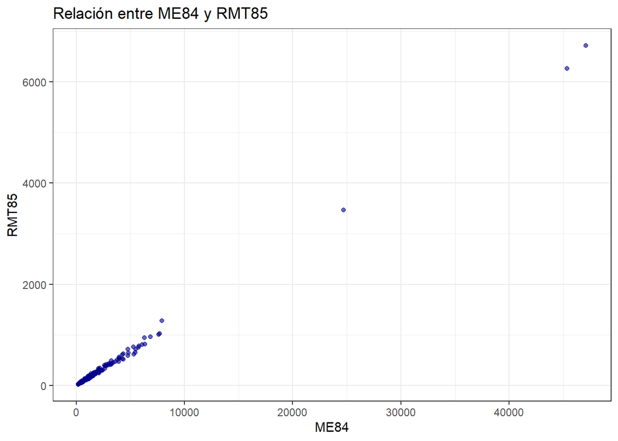

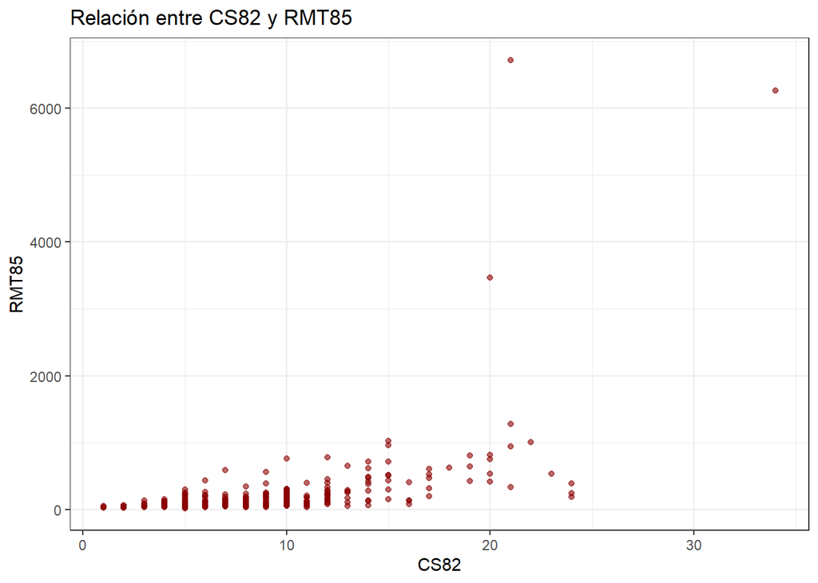

En este caso, `ME84` muestra una asociación más fuerte con `RMT85`, por lo que se considera una mejor candidata para calibrar.

Entonces, a continuación, se prueban otras tres calibraciones:

- Usando solo `ME84`
- Usando solo `CS82`.
- Usando ambas variables simultáneamente.

En cada caso se estima el total de `RMT85`, el error estándar, y se calcula el CV.

```r
tot_ME84 <- sum(datos$ME84)
diseno_cal3 <- calibrate(
  design = diseno,
  formula = ~ ME84 - 1,
  population = tot_ME84,
  aggregate = TRUE
)

total_cal3 <- svytotal(~RMT85, diseno_cal3)
cv3 <- cv(total_cal3)
```

```r
tot_CS82 <- sum(datos$CS82)
diseno_cal4 <- calibrate(
  design = diseno,
  formula = ~ CS82 - 1,
  population = tot_CS82,
  aggregate = TRUE
)

total_cal4 <- svytotal(~RMT85, diseno_cal4)
cv4 <- cv(total_cal4)
```

```r
tot_ambas <- c(tot_ME84, tot_CS82)
names(tot_ambas) <- c("ME84", "CS82")

diseno_cal5 <- calibrate(
  design = diseno,
  formula = ~ CS82 + ME84 - 1,
  population = tot_ambas,
  aggregate = TRUE
)

total_cal5 <- svytotal(~RMT85, diseno_cal5)
cv5 <- cv(total_cal5)
```

Comparación de métodos de calibración numérica

| Calibración | Total | SE | CV |
| --- | --- | --- | --- |
| ME84 | 68622.76 | 1350.542 | 0.020 |
| ME84+CS82 | 68624.25 | 1411.915 | 0.021 |
| Sin calibrar | 61000.00 | 9666.297 | 0.158 |
| CS82 | 58628.28 | 9770.023 | 0.167 |

Los resultados muestran que calibrar con `ME84` reduce más el CV que hacerlo con `CS82`, coherente con la correlación observada. Se observa también que usar ambas variables simultáneamente produce una reducción de variancia similar a utilizar solo `ME84`, pero en este caso es más óptimo utilizar a esta última como única variable auxiliar.

## Calibración usando la variable `ME84` y `TYPE`

Finalmente, se incorpora simultáneamente los totales poblacionales de `TYPE` y el total conocido de `ME84` en una única calibración. Esto combina información categórica y numérica dentro del diseño.

```r
tot_final <- c(113, 171, tot_ME84)
names(tot_final) <- c('TYPEH', 'TYPEM', 'ME84')

diseno_cal_final <- calibrate(
  design = diseno,
  formula = ~ ME84 + TYPE - 1,
  population = tot_final,
  aggregate = TRUE
)

total_final <- svytotal(~ RMT85, diseno_cal_final)
```

Resultado del diseño de calibración final

| Calibración | Estimación | SE | CV |
| --- | --- | --- | --- |
| ME84 + TYPE | 68404.97 | 1488.4 | 0.02 |

Este diseño mantiene el CV próximo a los observados para el diseño que considera sólo `ME84` y el que considera `CS82` y `ME84` a la vez.

## Conclusiones

En conclusión, comenzando desde un diseño por conglomerados relativamente simple, se fue incorporando información auxiliar mediante calibración para mejorar la precisión del estimador del total de `RMT85`. La calibración con la variable categórica permitió reducir la variabilidad, pero la mejora más importante se obtuvo al incluir variables numéricas relacionadas con la variable de interés, especialmente `ME84`, que mostró la mayor correlación y produjo el estimador más eficiente, mostrando cómo la incorporación adecuada de información auxiliar puede mejorar la calidad de las estimaciones sin necesidad de aumentar el tamaño muestral.